# Untitled

# Using Copilot (Basic) to analyse the data

## Initial prompt

Write the code to analyse the data in the attcheched csv file in R. I am wanting to predict the number of recruit at a plot (recruits) related to the percentage of soil crust at that site (crust). The file is called df_rec_saw.csv and is located in the folder data relative to the workspace.

Looking at df_rec_saw, the response variable is a count (recruits) with many zeros and some very large values (up to >100), so I would start with a *negative binomial GLM* and then assess whether there is evidence for excess zeros.

```r
# Packages
library(tidyverse)
library(MASS)
library(DHARMa)
library(performance)
library(ggeffects)
library(patchwork)
# Read data
df <- read_csv("data/df_rec_saw.csv")
# Inspect data
glimpse(df)
```

```
Rows: 320
Columns: 2
$ crust    <dbl> 0.42, 0.14, 0.00, 0.00, 0.59, 0.79, 0.04, 0.22, 0.08, 0.15, 0…
$ recruits <dbl> 0, 11, 0, 1, 0, 0, 6, 0, 4, 0, 0, 5, 0, 0, 1, 0, 68, 1, 2, 0,…
```

```r
summary(df)
```

```
     crust           recruits
 Min.   :0.0000   Min.   :  0.000
 1st Qu.:0.0500   1st Qu.:  0.000
 Median :0.3350   Median :  1.000
 Mean   :0.3708   Mean   :  8.134
 3rd Qu.:0.6500   3rd Qu.:  6.000
 Max.   :0.9000   Max.   :161.000
```

```r
# Proportion of zeros
mean(df$recruits == 0)
```

```
[1] 0.49375
```

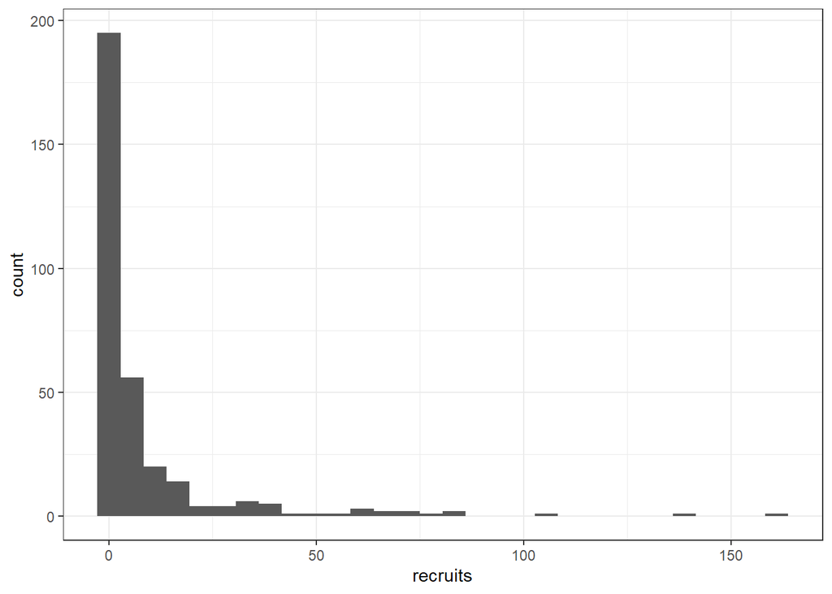

```r
# Histogram of recruits
ggplot(df, aes(recruits)) +
  geom_histogram(bins = 30) +
  theme_bw()
```

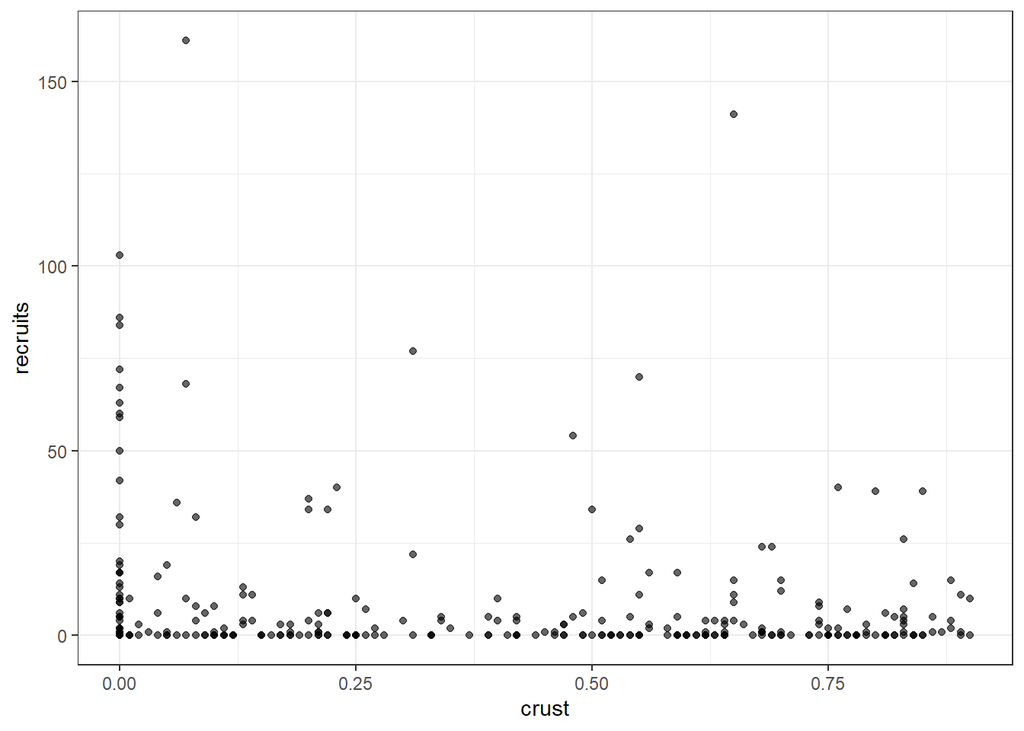

```r
# Scatterplot
ggplot(df, aes(crust, recruits)) +
  geom_point(alpha = 0.6) +
  theme_bw()
```

### Fit models

Fit both a Poisson and negative binomial model and compare them.

```r
# Poisson GLM
m_pois <- glm(
  recruits ~ crust,
  family = poisson,
  data = df
)

# Negative binomial GLM
m_nb <- glm.nb(
  recruits ~ crust,
  data = df
)

summary(m_pois)
```

```
Call:
glm(formula = recruits ~ crust, family = poisson, data = df)

Coefficients:
            Estimate Std. Error z value Pr(>|z|)
(Intercept)  2.45970    0.02693   91.35   <2e-16 ***
crust       -1.14124    0.06864  -16.63   <2e-16 ***
---
Signif. codes:  0 '***' 0.001 '**' 0.01 '*' 0.05 '.' 0.1 ' ' 1

(Dispersion parameter for poisson family taken to be 1)

    Null deviance: 7497.9  on 319  degrees of freedom
Residual deviance: 7203.0  on 318  degrees of freedom
AIC: 7825.5

Number of Fisher Scoring iterations: 6
```

```r
summary(m_nb)
```

```
Call:
glm.nb(formula = recruits ~ crust, data = df, init.theta = 0.1924326874,
    link = log)

Coefficients:
            Estimate Std. Error z value Pr(>|z|)
(Intercept)   2.4275     0.2015  12.047   <2e-16 ***
crust        -1.0397     0.4202  -2.475   0.0133 *
---
Signif. codes:  0 '***' 0.001 '**' 0.01 '*' 0.05 '.' 0.1 ' ' 1

(Dispersion parameter for Negative Binomial(0.1924) family taken to be 1)

    Null deviance: 298.47  on 319  degrees of freedom
Residual deviance: 291.97  on 318  degrees of freedom
AIC: 1605.5

Number of Fisher Scoring iterations: 1

              Theta:  0.1924
          Std. Err.:  0.0185

 2 x log-likelihood:  -1599.4900
```

```r
AIC(m_pois, m_nb)
```

```
       df      AIC
m_pois  2 7825.488
m_nb    3 1605.490
```

### Check overdispersion

```r
check_overdispersion(m_pois)
```

```
# Overdispersion test

       dispersion ratio =    43.409
  Pearson's Chi-Squared = 13803.924
                p-value =   < 0.001
```

```
Overdispersion detected.
```

```r
check_overdispersion(m_nb)
```

```
# Overdispersion test

 dispersion ratio = 0.976
          p-value = 0.896
```

```
No overdispersion detected.
```

A dispersion ratio >> 1 for the Poisson model would indicate overdispersion and support using the negative binomial.

### Model diagnostics

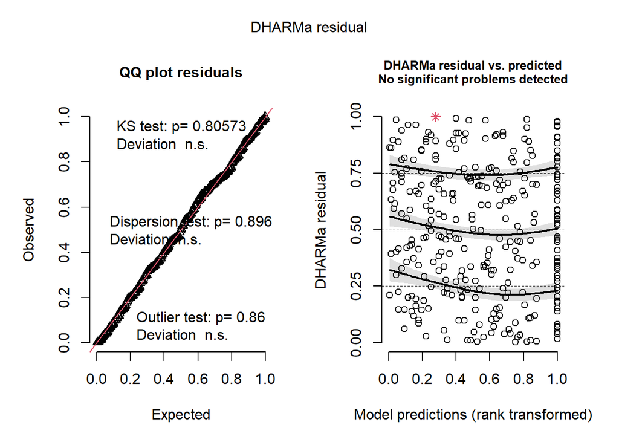

```r
sim_nb <- simulateResiduals(m_nb)

plot(sim_nb)
```

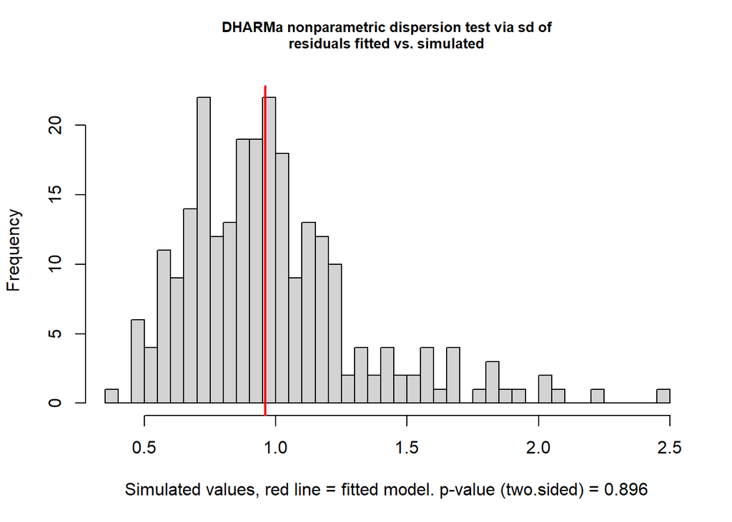

```
    DHARMa nonparametric dispersion test via sd of residuals fitted vs.
    simulated

data:  simulationOutput
dispersion = 0.97584, p-value = 0.896
alternative hypothesis: two.sided
```

```r
testDispersion(sim_nb)
```

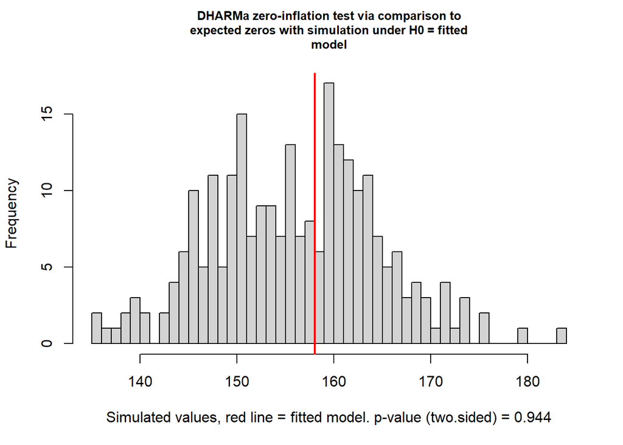

```
    DHARMa zero-inflation test via comparison to expected zeros with
    simulation under H0 = fitted model

data:  simulationOutput
ratioObsSim = 1.0093, p-value = 0.944
alternative hypothesis: two.sided
```

```r
testZeroInflation(sim_nb)
```

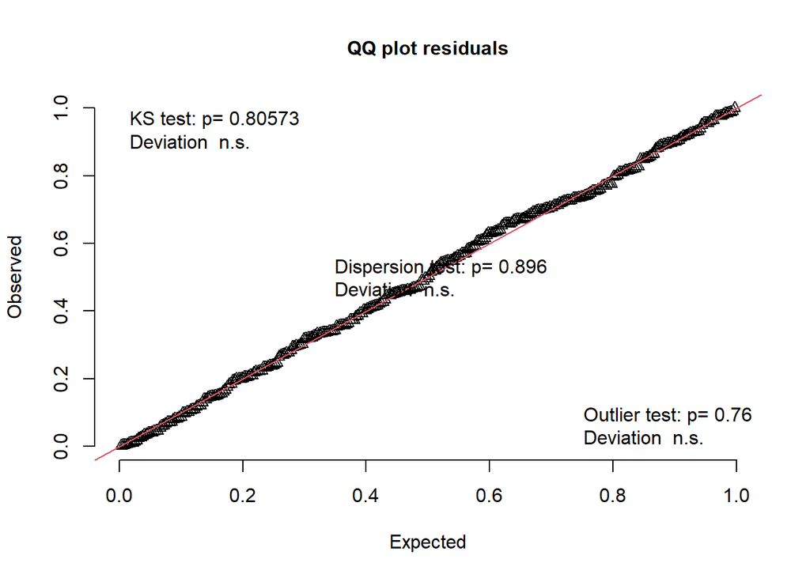

```
    Asymptotic one-sample Kolmogorov-Smirnov test

data:  simulationOutput$scaledResiduals
D = 0.035836, p-value = 0.8057
alternative hypothesis: two-sided
```

```r
testUniformity(sim_nb)
```

The zero-inflation test will indicate whether you need a zero-inflated model.

### Effect size

```r
summary(m_nb)
```

```
Call:
glm.nb(formula = recruits ~ crust, data = df, init.theta = 0.1924326874,
    link = log)

Coefficients:
            Estimate Std. Error z value Pr(>|z|)
(Intercept)   2.4275     0.2015  12.047   <2e-16 ***
crust        -1.0397     0.4202  -2.475   0.0133 *
---
Signif. codes:  0 '***' 0.001 '**' 0.01 '*' 0.05 '.' 0.1 ' ' 1

(Dispersion parameter for Negative Binomial(0.1924) family taken to be 1)

    Null deviance: 298.47  on 319  degrees of freedom
Residual deviance: 291.97  on 318  degrees of freedom
AIC: 1605.5

Number of Fisher Scoring iterations: 1

              Theta:  0.1924
          Std. Err.:  0.0185

 2 x log-likelihood:  -1599.4900
```

```r
exp(coef(m_nb))
```

```
(Intercept)       crust
 11.3309973   0.3535519
```

The exponentiated coefficient gives the multiplicative change in expected recruits for a one-unit increase in crust.

Because crust ranges from 0 to ~0.9, it is often easier to interpret a 10% increase:

```r
beta <- coef(m_nb)["crust"]

exp(beta * 0.1)
```

```
    crust
0.9012501
```

### Predicted relationship

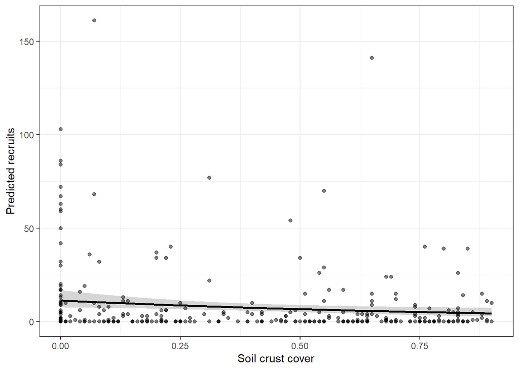

```r
pred <- ggpredict(m_nb, terms = "crust [all]")

ggplot(pred,
       aes(x = x, y = predicted)) +
  geom_ribbon(aes(ymin = conf.low,
                  ymax = conf.high),
              alpha = 0.2) +
  geom_line(linewidth = 1) +
  geom_point(data = df,
             aes(crust, recruits),
             inherit.aes = FALSE,
             alpha = 0.5) +
  labs(
    x = "Soil crust cover",
    y = "Predicted recruits"
  ) +
  theme_bw()
```

### Cook’s distance

Given the very large counts in some plots, I would also examine influential observations.

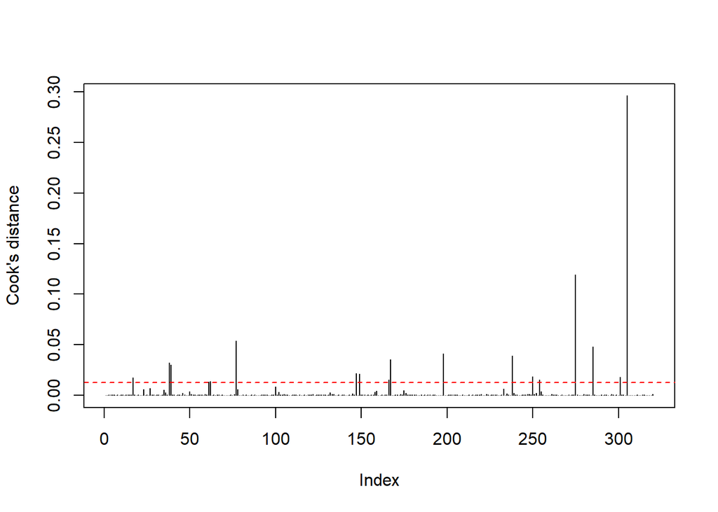

```r
cook <- cooks.distance(m_nb)

plot(cook,
     type = "h",
     ylab = "Cook's distance")

abline(
  h = 4 / nrow(df),
  col = "red",
  lty = 2
)
```

```r
which(cook > 4 / nrow(df))
```

```
 17  38  39  61  62  77 147 149 166 167 198 238 250 254 275 285 301 305
 17  38  39  61  62  77 147 149 166 167 198 238 250 254 275 285 301 305
```

```r
df[cook > 4 / nrow(df), ]
```

```
# A tibble: 18 × 2
   crust recruits
   <dbl>    <dbl>
 1  0.07       68
 2  0          86
 3  0          84
 4  0          59
 5  0          60
 6  0.85       39
 7  0.31       77
 8  0          72
 9  0.48       54
10  0.76       40
11  0.8        39
12  0.55       70
13  0.83       26
14  0          63
15  0.07      161
16  0         103
17  0          67
18  0.65      141
```

### Optional GAM for nonlinearity

If the residuals suggest a nonlinear response to crust:

```r
library(mgcv)
m_gam <- gam(
  recruits ~ s(crust),
  family = nb(),
  data = df,
  method = "REML"
)

summary(m_gam)
```

```
Family: Negative Binomial(0.191)
Link function: log

Formula:
recruits ~ s(crust)

Parametric coefficients:
            Estimate Std. Error z value Pr(>|z|)
(Intercept)   2.0405     0.1296   15.74   <2e-16 ***
---
Signif. codes:  0 '***' 0.001 '**' 0.01 '*' 0.05 '.' 0.1 ' ' 1

Approximate significance of smooth terms:
           edf Ref.df Chi.sq p-value
s(crust) 1.104    1.2  5.661    0.02 *
---
Signif. codes:  0 '***' 0.001 '**' 0.01 '*' 0.05 '.' 0.1 ' ' 1

R-sq.(adj) =  0.0186   Deviance explained = 2.24%
-REML = 802.04  Scale est. = 1         n = 320
```

```r
AIC(m_nb, m_gam)
```

```
            df      AIC
m_nb  3.000000 1605.490
m_gam 3.200027 1605.706
```

Plot the fitted smooth:

[figure not shown]

```r
plot(m_gam, shade = TRUE)
```

Or:

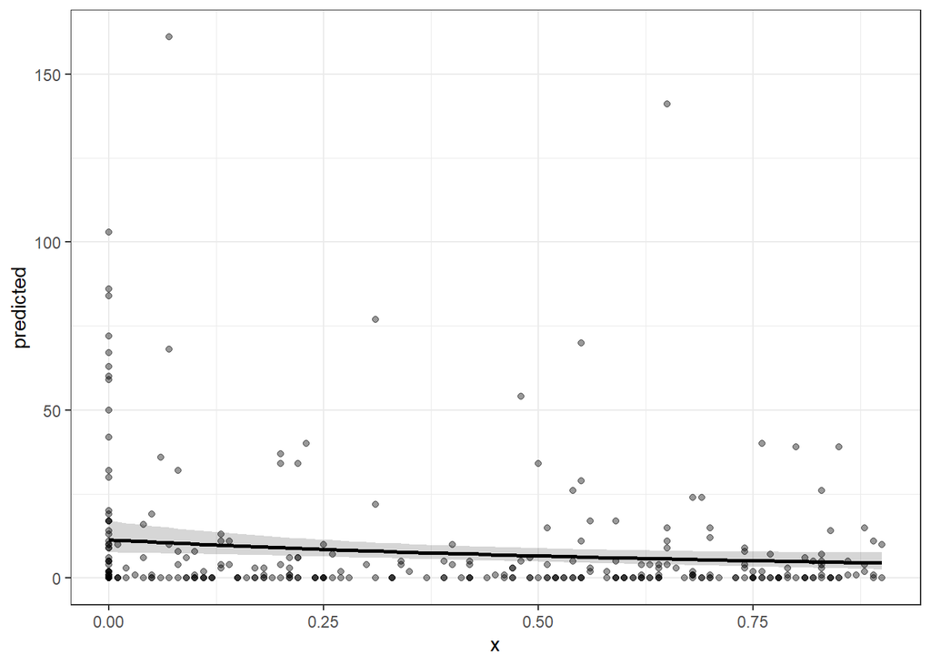

```r
pred_gam <- ggpredict(m_gam, terms = "crust [all]")

ggplot(pred_gam,
       aes(x = x, y = predicted)) +
  geom_ribbon(aes(ymin = conf.low,
                  ymax = conf.high),
              alpha = 0.2) +
  geom_line(linewidth = 1) +
  geom_point(data = df,
             aes(crust, recruits),
             inherit.aes = FALSE,
             alpha = 0.4) +
  theme_bw()
```

Given the structure of this dataset, my expectation is that the *negative binomial model will strongly outperform Poisson due to overdispersion*, and the DHARMa zero-inflation test will determine whether a zero-inflated negative binomial is warranted.

From that we can see that the *negative binomial* model out performs the Poisson model, and in the negative binomial model there is no extra zero-inflation and it isn’t really improved with a non-linearity.

## Write-up prompt

The quarto document that Copilot produced didn’t include any references, even though I explicitly asked for them.

One thing I would recommend is replacing the generic Results text with automatically generated values such as the coefficient estimate, standard error, confidence interval, AIC difference, and p-value from the crust effect. That makes the report fully reproducible and publication-ready.

## Update to write-up prompt

You didn’t include any references. Can you please update the quarto file by adding appropriate references and the bibtex file that would go with them and add the automatically generated values like you suggested.

Good point. The previous version cited packages in the text but did not actually use citation keys, so nothing would appear in the References section.

A better approach is to cite the statistical methods that justify:

1. Generalized linear models.
2. Negative binomial regression for overdispersed counts.
3. Generalized additive models.
4. DHARMa residual diagnostics.
5. R itself.

### references.bib

```
@book{mccullagh1989,
  title = {Generalized Linear Models},
  author = {McCullagh, Peter and Nelder, John A.},
  edition = {2},
  year = {1989},
  publisher = {Chapman and Hall},
  address = {London}
}

@book{venables2002,
  title = {Modern Applied Statistics with S},
  author = {Venables, William N. and Ripley, Brian D.},
  edition = {4},
  year = {2002},
  publisher = {Springer},
  address = {New York}
}

@book{wood2017,
  title = {Generalized Additive Models: An Introduction with R},
  author = {Wood, Simon N.},
  edition = {2},
  year = {2017},
  publisher = {Chapman and Hall/CRC},
  address = {Boca Raton}
}

@article{hartig2022,
  title = {DHARMa: Residual Diagnostics for Hierarchical (Multi-Level / Mixed) Regression Models},
  author = {Hartig, Florian},
  year = {2022},
  journal = {R package version 0.4.6}
}

@manual{R,
  title = {R: A Language and Environment for Statistical Computing},
  author = {{R Core Team}},
  year = {2026},
  organization = {R Foundation for Statistical Computing},
  address = {Vienna, Austria}
}
```

One additional improvement I would make for a report intended for publication would be to report the actual predicted effect over a biologically meaningful range (e.g. 0% to 50% crust cover) rather than the default “one-unit increase” on a 0-1 scale. That is generally much easier for readers to interpret.

Let’s see the effect of the Copilot suggestion.

Okay, update the report as you suggested to the actual predicted effect over the range 0% ot 50%.

Yes, I think that’s a much more meaningful effect size. A “1-unit increase” corresponds to going from 0% crust to 100% crust cover, which is not especially intuitive. Reporting the predicted change from 0% to 50% crust cover is easier for readers to interpret.

You could also strengthen the interpretation further by reporting a contrast across the observed interquartile range of crust cover rather than an arbitrary 0% to 50% change:

```r
q <- quantile(df$crust, probs = c(0.25, 0.75))

effect_iqr <- exp(beta * diff(q))
```

and then write:

> “Plots at the 75th percentile of soil crust cover were predicted to have X times the recruitment of plots at the 25th percentile.”

This is often preferred in ecological journals because it describes the effect over a realistic range actually observed in the data rather than a hypothetical range.

I am not sure how many more suggestions it will make, but let’s leave it there.